# Estatística1VA

Gilmar Rodrigues Campelo

2023-01-26

# Análise da Ocorrencia de Enterococcus nas Prais do Lintoral Paulista

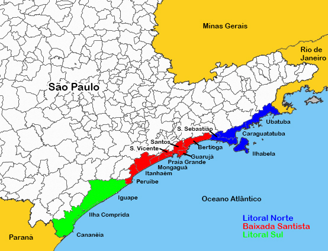

Litoral Paulista

Fonte:https://upload.wikimedia.org/wikipedia/commons/0/08/LitoralPaulista.jpg

# 1 Banco de Dados

O banco de dados tráz a ocorrência do Enterococcus nas prais do litoral paulista.

A área selecionada foi a da região de Mongaguá

# 2 Pacotes Carregados

library(readxl)

library(magrittr)

library(dplyr)

library(ggplot2)

## 2.1 BLOCO PARA SELECIONAR A CIDADE DE MONGAGUÁ

dados <- read_excel(path = “C:/Users/gilma/OneDrive/Documentos/UFRPE/Estatistica/Projeto1VA/sp_beaches.xlsx”)%>% filter(City == ‘MONGAGUÁ’)

## 2.2 TRANSFORMA A COLUNA ENTEROCCCUS EM NUMERICA

Nessa etapa os dados da coluna entereroccus foi transformada em numérica

## 2.3 CALCULAR AS MEDIAS

summarise(Media=mean(Enterococcus),DesvioPadrao=sd(Enterococcus), Mediana=median(Enterococcus),Q1=quantile(Enterococcus, probs = 0.25), Q3=quantile(Enterococcus, probs = 0.75),Minimo=min(Enterococcus), Maximo=max(Enterococcus))

# 3 Código

## 3.1 Pacotes

```r
library(readxl)
library(magrittr)
library(dplyr)
library(ggplot2)
```

## 3.2 Gerar Dados Brutos

### 3.2.1 Dados Brutos em Páginas

Os dados brutos são referentes a todas as prais da cidade de Mongaguá e estão dispostos em páginas.

```r
dados2 <-  read_excel(path = "C:/Users/gilma/OneDrive/Documentos/UFRPE/Estatistica/Projeto1VA/sp_beaches.xlsx")%>%
  filter(City == 'MONGAGUÁ')%>%
  mutate( Enterococcus=as.numeric(Enterococcus))
library(rmarkdown)
paged_table(dados2)
```

| City | Beach | Date | Enterococcus |
| --- | --- | --- | --- |
| MONGAGUÁ | ITAPOÃ - VILA SÃO PAULO | 2012-01-03 | 22 |
| MONGAGUÁ | ITAPOÃ - VILA SÃO PAULO | 2012-01-08 | 75 |
| MONGAGUÁ | ITAPOÃ - VILA SÃO PAULO | 2012-01-15 | 4 |
| MONGAGUÁ | ITAPOÃ - VILA SÃO PAULO | 2012-01-22 | 100 |
| MONGAGUÁ | ITAPOÃ - VILA SÃO PAULO | 2012-01-29 | 10 |
| MONGAGUÁ | ITAPOÃ - VILA SÃO PAULO | 2012-02-05 | 162 |
| MONGAGUÁ | ITAPOÃ - VILA SÃO PAULO | 2012-02-12 | 128 |
| MONGAGUÁ | ITAPOÃ - VILA SÃO PAULO | 2012-02-19 | 252 |
| MONGAGUÁ | ITAPOÃ - VILA SÃO PAULO | 2012-02-26 | 17 |
| MONGAGUÁ | ITAPOÃ - VILA SÃO PAULO | 2012-03-04 | 1 |

[output cut: 3073 more lines]

## 3.3 Carregando MÉDIAS

Apresentação da média, desvio padrão, dediana e os quartis com ponto

mínimo e máximo.

```r
dados <- read_excel(path = "C:/Users/gilma/OneDrive/Documentos/UFRPE/Estatistica/Projeto1VA/sp_beaches.xlsx")%>%
  filter(City == 'MONGAGUÁ')%>%
  group_by(Beach)%>% mutate( Enterococcus=as.numeric(Enterococcus))%>%
  summarise(Media=mean(Enterococcus),DesvioPadrao=sd(Enterococcus),
            Mediana=median(Enterococcus),Q1=quantile(Enterococcus, probs = 0.25),
            Q3=quantile(Enterococcus, probs = 0.75),Minimo=min(Enterococcus),
            Maximo=max(Enterococcus))
```

```r
library(rmarkdown)
paged_table(dados)
```

| Beach | Media | DesvioPadrao | Mediana | Q1 | Q3 | Minimo | Maximo |
| --- | --- | --- | --- | --- | --- | --- | --- |
| AGENOR DE CAMPOS | 79.95464 | 134.1573 | 18 | 6.0 | 80.0 | 1 | 940 |
| CENTRAL | 75.68683 | 127.2464 | 23 | 7.0 | 80.0 | 1 | 1100 |
| FLÓRIDA MIRIM | 69.67622 | 118.6334 | 13 | 4.0 | 80.0 | 1 | 512 |
| ITAÓCA | 74.21253 | 134.3112 | 18 | 5.5 | 72.5 | 1 | 1040 |
| ITAPOÃ - VILA SÃO PAULO | 72.56823 | 121.2461 | 20 | 6.5 | 82.0 | 1 | 900 |
| SANTA EUGÊNIA | 79.47228 | 140.8460 | 20 | 6.0 | 76.0 | 1 | 1260 |
| VERA CRUZ | 79.01944 | 139.2889 | 20 | 7.0 | 80.0 | 1 | 1160 |

# 4 GRÁFICOS

## 4.1 GRAFICO DE FREQUENCIA EM ORDEM CRESCENTE

Gráfico da ocorrencia de enterococcus nas prais em percentual e em ordem

crescente.

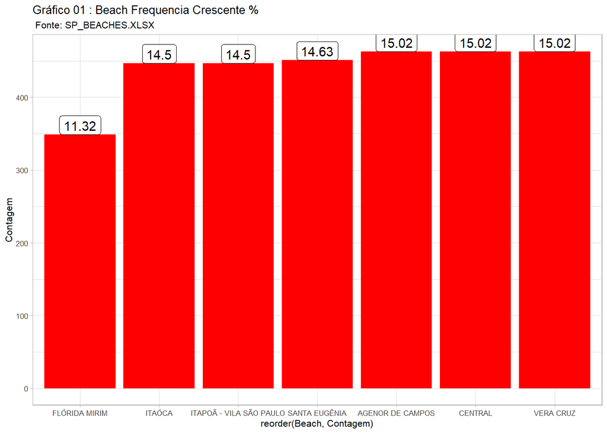

```r
grafico01
```

## 4.2 GRÁFICO DE FREQUENCIA EM ORDEM DECRESCENTE

Gráfico da ocorrencia de enterococcus nas prais em percentual e em ordem

decrescente.

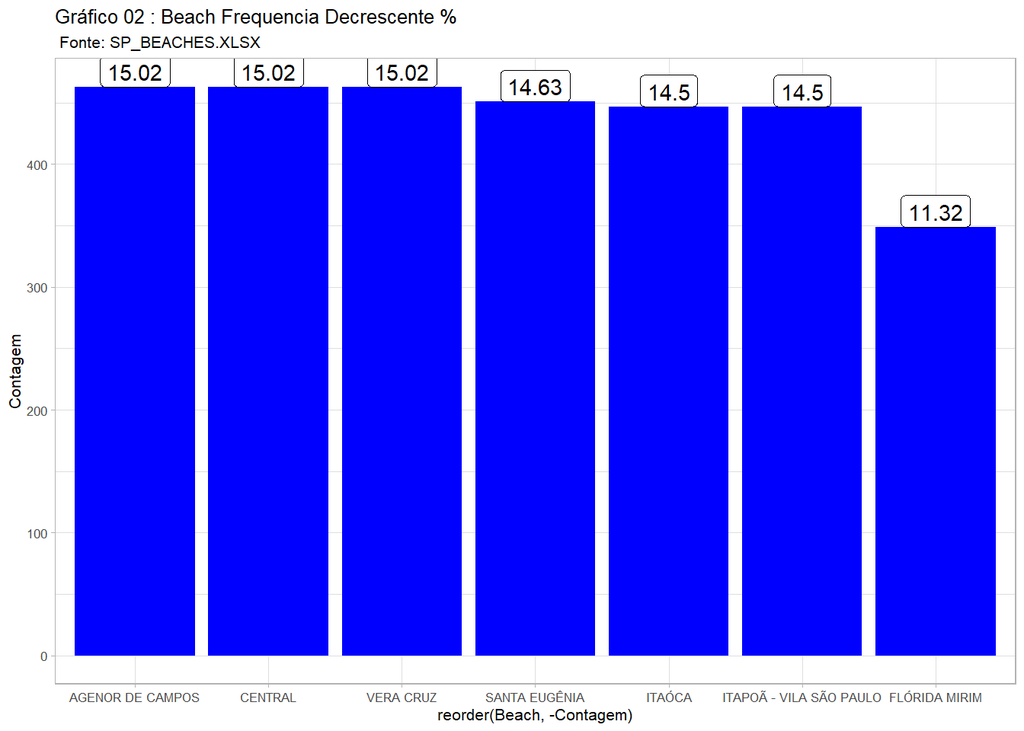

```r
grafico02
```

## 4.3 GRAFICO EM PIZZA

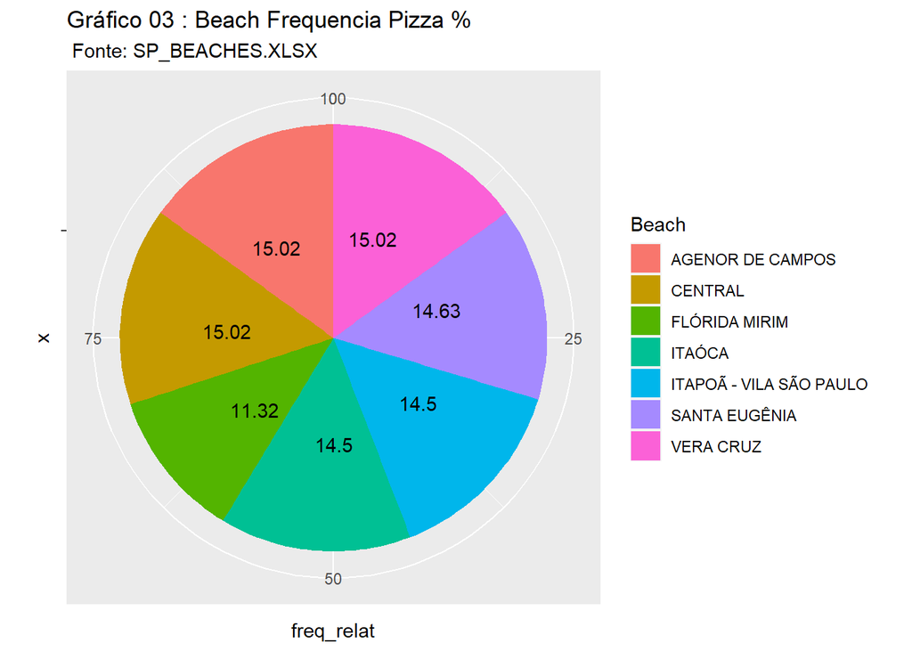

```r
grafico03
```

## 4.4 GRÁFICO EM PIZZA

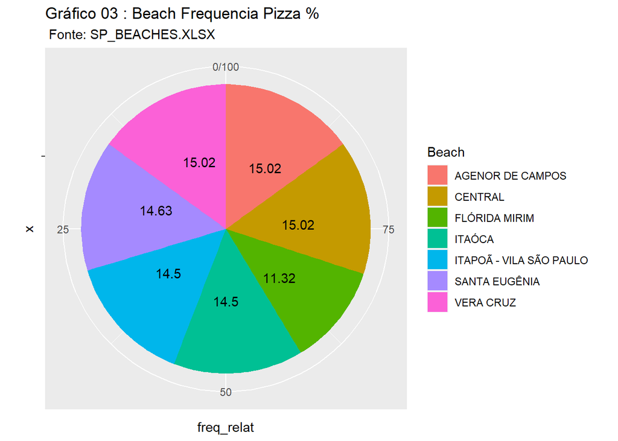

```r
grafico04
```

## 4.5 Gráfico Histograma Enterococcus

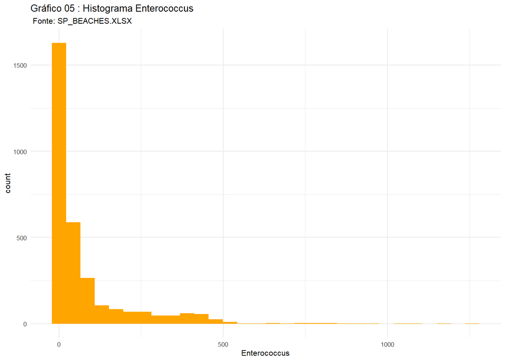

```r
grafico05
```

## 4.6 Boxplot Beach x Enterococcus

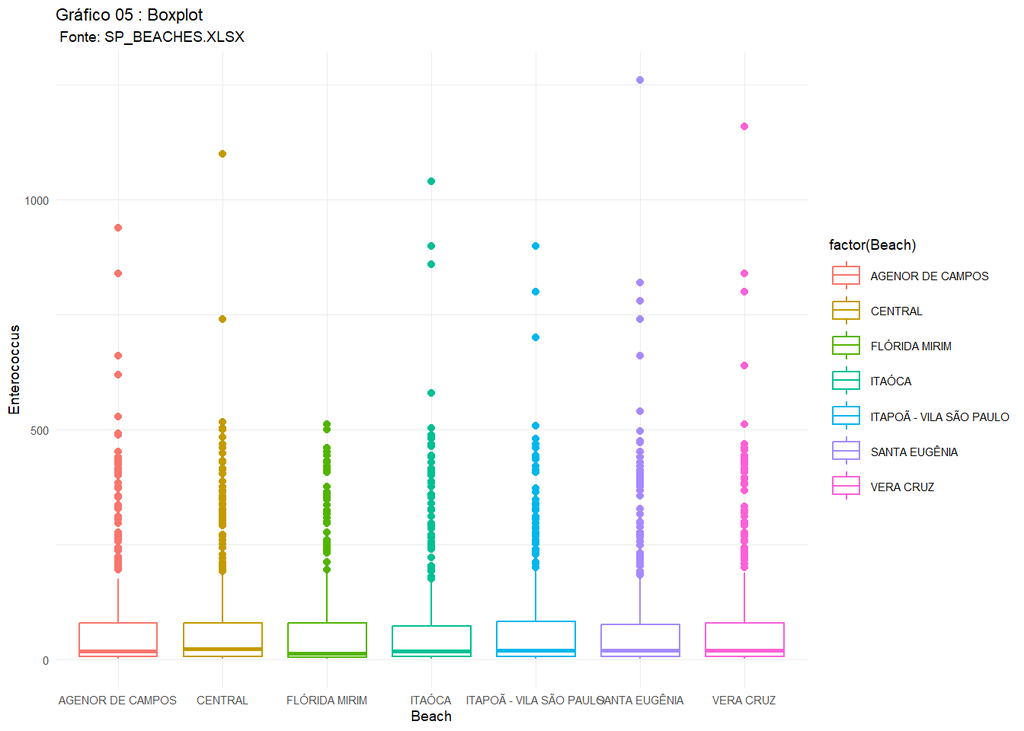

```r
 ggplot(dados2, aes(x = Beach, y = Enterococcus)) +
  geom_boxplot(aes(color=factor(Beach)))+
  labs(title = "Gráfico 05 : Boxplot" ,
  subtitle = " Fonte: SP_BEACHES.XLSX")+
  theme_minimal(base_size = 7)
```